# Practica guiada 2 - Tunning de árboles

## Tunning de Árboles de Decisión con Tidymodels

## Dataset

El dataset corresponde a Boston, que se encuentra disponible en Kaggle; una plataforma de competencia de machine learning. Más info en: https://www.cs.toronto.edu/~delve/data/boston/bostonDetail.html

#### Cargo las librerias

```r
#si no tengo instalado la libreria, la instalo
#install.packages(tidymodels)
```

```r
library(tidymodels)
library(tidyverse)
library(magrittr)
library(corrr)
library(MASS) #el dataset se encuentra en esta librería
```

#### Ingreso los datos

```r
data(Boston)
```

### División de los datos

En primera instancia dividimos en TRAIN Y TEST

```r
set.seed(1234)
p_split <- Boston %>%
    initial_split(prop = 0.75)
p_train <- training(p_split)
p_test <- testing(p_split)

glimpse(p_train)
```

```
## Rows: 379
## Columns: 14
## $ crim    <dbl> 0.01501, 0.03961, 67.92080, 0.14866, 0.10574, 0.10793, 11.5779…
## $ zn      <dbl> 90, 0, 0, 0, 0, 0, 0, 0, 0, 0, 0, 0, 0, 0, 0, 0, 0, 0, 0, 20, …
## $ indus   <dbl> 1.21, 5.19, 18.10, 8.56, 27.74, 8.56, 18.10, 21.89, 18.10, 18.…
## $ chas    <int> 1, 0, 0, 0, 0, 0, 0, 0, 0, 0, 0, 0, 0, 0, 0, 0, 0, 0, 0, 1, 0,…
## $ nox     <dbl> 0.401, 0.515, 0.693, 0.520, 0.609, 0.520, 0.700, 0.624, 0.718,…
## $ rm      <dbl> 7.923, 6.037, 5.683, 6.727, 5.983, 6.195, 5.036, 6.372, 6.006,…
## $ age     <dbl> 24.8, 34.5, 100.0, 79.9, 98.8, 54.4, 97.0, 97.9, 95.3, 77.8, 8…
## $ dis     <dbl> 5.8850, 5.9853, 1.4254, 2.7778, 1.8681, 2.7778, 1.7700, 2.3274…
## $ rad     <int> 1, 5, 24, 5, 4, 5, 24, 4, 24, 24, 24, 2, 5, 4, 2, 5, 5, 24, 24…
## $ tax     <dbl> 198, 224, 666, 384, 711, 384, 666, 437, 666, 666, 666, 276, 38…
## $ ptratio <dbl> 13.6, 20.2, 20.2, 20.9, 20.1, 20.9, 20.2, 21.2, 20.2, 20.2, 20…
## $ black   <dbl> 395.52, 396.90, 384.97, 394.76, 390.11, 393.49, 396.90, 385.76…
## $ lstat   <dbl> 3.16, 8.01, 22.98, 9.42, 18.07, 13.00, 25.68, 11.12, 15.70, 29…
## $ medv    <dbl> 50.0, 21.1, 5.0, 27.5, 13.6, 21.7, 9.7, 23.0, 14.2, 6.3, 7.4, …
```

```r
p_split
```

```
## <Analysis/Assess/Total>
## <379/127/506>
```

```r
head(p_test)
```

```
##       crim   zn indus chas   nox    rm   age    dis rad tax ptratio  black
## 1  0.00632 18.0  2.31    0 0.538 6.575  65.2 4.0900   1 296    15.3 396.90
## 5  0.06905  0.0  2.18    0 0.458 7.147  54.2 6.0622   3 222    18.7 396.90
## 7  0.08829 12.5  7.87    0 0.524 6.012  66.6 5.5605   5 311    15.2 395.60
## 8  0.14455 12.5  7.87    0 0.524 6.172  96.1 5.9505   5 311    15.2 396.90
## 9  0.21124 12.5  7.87    0 0.524 5.631 100.0 6.0821   5 311    15.2 386.63
## 11 0.22489 12.5  7.87    0 0.524 6.377  94.3 6.3467   5 311    15.2 392.52
##    lstat medv
## 1   4.98 24.0
## 5   5.33 36.2
## 7  12.43 22.9
## 8  19.15 27.1
## 9  29.93 16.5
## 11 20.45 15.0
```

#### Voy a crear los folds de validación cruzada a partir de los datos de TRAIN

```r
p_folds <- vfold_cv(p_train, v=3)
```

Veo los splits creados en la validación cruzada

```r
p_folds$splits
```

```
## [[1]]
## <Analysis/Assess/Total>
## <252/127/379>
##
## [[2]]
## <Analysis/Assess/Total>
## <253/126/379>
##
## [[3]]
## <Analysis/Assess/Total>
## <253/126/379>
```

### Preprocesamiento

```r
recipe_dt <- p_train %>%
  recipe(medv~.) %>%
  step_corr(all_predictors()) %>% #elimino las correlaciones
  step_center(all_predictors(), -all_outcomes()) %>% #centrado
  step_scale(all_predictors(), -all_outcomes()) %>% #escalado
  prep()
```

### Modelo

Aca vamos a especificar las variables que vamos a hacer tunning de estas variables.

```r
tree_spec <- decision_tree(
  cost_complexity = tune(),
  tree_depth = tune(),
  min_n = tune()
) %>%
  set_engine("rpart") %>%
  set_mode("regression")

tree_spec
```

```
## Decision Tree Model Specification (regression)
##
## Main Arguments:
##   cost_complexity = tune()
##   tree_depth = tune()
##   min_n = tune()
##
## Computational engine: rpart
```

Veamos los posibles valores en esta grilla.

```r
tree_grid <- grid_regular(cost_complexity(), tree_depth(), min_n(), levels = 4)

tree_grid
```

```
## # A tibble: 64 × 3
##    cost_complexity tree_depth min_n
##              <dbl>      <int> <int>
##  1    0.0000000001          1     2
##  2    0.0000001             1     2
##  3    0.0001                1     2
##  4    0.1                   1     2
##  5    0.0000000001          5     2
##  6    0.0000001             5     2
##  7    0.0001                5     2
##  8    0.1                   5     2
##  9    0.0000000001         10     2
## 10    0.0000001            10     2
## # … with 54 more rows
```

### Tunning del modelo de árboles de decisión

En esta etapa vamos a hacer el tuneo de los hiperparámetros que hemos definido anteriormente. Vamos a consignar las métricas de regresión usuales.

**Importante**: Los datos son los folds de la validación cruzada.

```r
doParallel::registerDoParallel() #paralelizamos los cálculos

set.seed(345)
tree_rs <- tune_grid(
  tree_spec,
  medv ~ .,
  resamples = p_folds,
  grid = tree_grid,
  metrics = metric_set(rmse, rsq, mae)
)

tree_rs
```

```
## # Tuning results
## # 3-fold cross-validation
## # A tibble: 3 × 4
##   splits            id    .metrics           .notes
##   <list>            <chr> <list>             <list>
## 1 <split [252/127]> Fold1 <tibble [192 × 7]> <tibble [0 × 1]>
## 2 <split [253/126]> Fold2 <tibble [192 × 7]> <tibble [0 × 1]>
## 3 <split [253/126]> Fold3 <tibble [192 × 7]> <tibble [0 × 1]>
```

## Predicciones en TRAIN

```r
collect_metrics(tree_rs)
```

```
## # A tibble: 192 × 9
##    cost_complexity tree_depth min_n .metric .estimator  mean     n std_err
##              <dbl>      <int> <int> <chr>   <chr>      <dbl> <int>   <dbl>
##  1    0.0000000001          1     2 mae     standard   5.44      3  0.276
##  2    0.0000000001          1     2 rmse    standard   7.23      3  0.277
##  3    0.0000000001          1     2 rsq     standard   0.395     3  0.0420
##  4    0.0000001             1     2 mae     standard   5.44      3  0.276
##  5    0.0000001             1     2 rmse    standard   7.23      3  0.277
##  6    0.0000001             1     2 rsq     standard   0.395     3  0.0420
##  7    0.0001                1     2 mae     standard   5.44      3  0.276
##  8    0.0001                1     2 rmse    standard   7.23      3  0.277
##  9    0.0001                1     2 rsq     standard   0.395     3  0.0420
## 10    0.1                   1     2 mae     standard   5.44      3  0.276
## # … with 182 more rows, and 1 more variable: .config <fct>
```

```r
tree_rs %>%
  collect_metrics(summarize=FALSE)
```

```
## # A tibble: 576 × 8
##    id    cost_complexity tree_depth min_n .metric .estimator .estimate .config
##    <chr>           <dbl>      <int> <int> <chr>   <chr>          <dbl> <fct>
##  1 Fold1    0.0000000001          1     2 rmse    standard       6.85  Preproce…
##  2 Fold1    0.0000000001          1     2 rsq     standard       0.328 Preproce…
##  3 Fold1    0.0000000001          1     2 mae     standard       4.94  Preproce…
##  4 Fold2    0.0000000001          1     2 rmse    standard       7.07  Preproce…
##  5 Fold2    0.0000000001          1     2 rsq     standard       0.472 Preproce…
##  6 Fold2    0.0000000001          1     2 mae     standard       5.51  Preproce…
##  7 Fold3    0.0000000001          1     2 rmse    standard       7.77  Preproce…
##  8 Fold3    0.0000000001          1     2 rsq     standard       0.386 Preproce…
##  9 Fold3    0.0000000001          1     2 mae     standard       5.89  Preproce…
## 10 Fold1    0.0000001             1     2 rmse    standard       6.85  Preproce…
## # … with 566 more rows
```

#### Ploteamos los hiperparámetros

Vamos a plotear los 3 hiperparámetros q hicimos tunning, lo hacemos mediante la función autoplot() disponible en tidymodels.

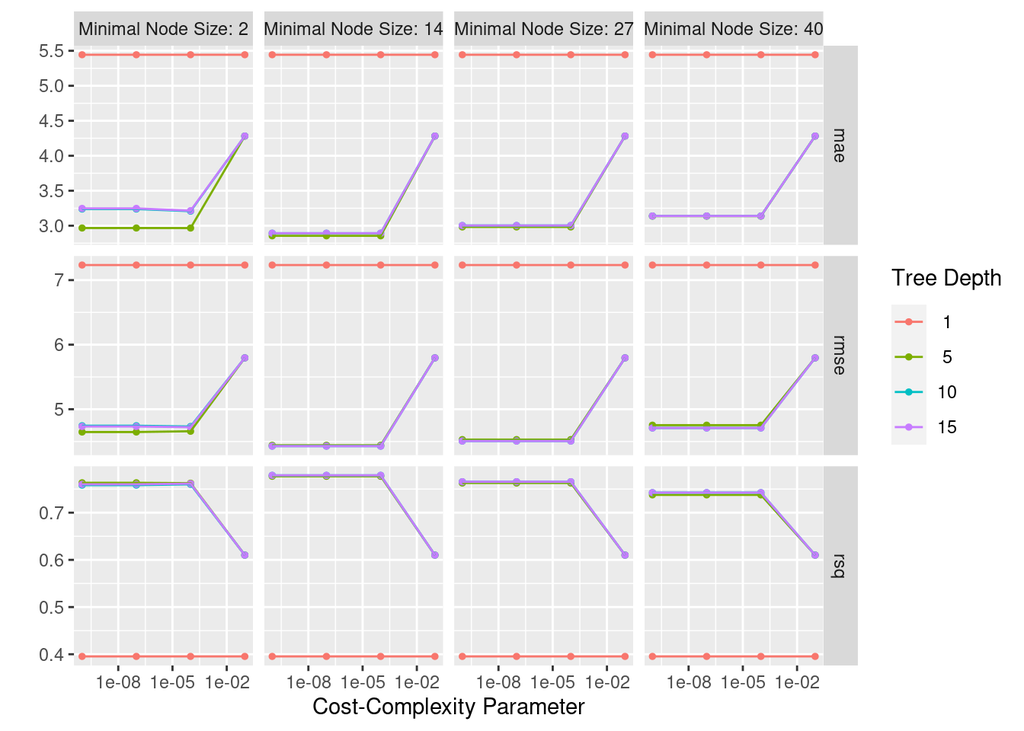

```r
autoplot(tree_rs)
```

### El mejor modelo

```r
show_best(tree_rs)
```

```
## # A tibble: 5 × 9
##   cost_complexity tree_depth min_n .metric .estimator  mean     n std_err
##             <dbl>      <int> <int> <chr>   <chr>      <dbl> <int>   <dbl>
## 1    0.0000000001         10    14 rmse    standard    4.43     3   0.337
## 2    0.0000001            10    14 rmse    standard    4.43     3   0.337
## 3    0.0001               10    14 rmse    standard    4.43     3   0.337
## 4    0.0000000001         15    14 rmse    standard    4.43     3   0.337
## 5    0.0000001            15    14 rmse    standard    4.43     3   0.337
## # … with 1 more variable: .config <fct>
```

## Finalizamos el modelo

En esta etapa finalizamos el modelo, con el mejor valor de rsme obtenido, vamos a elegir este modelo.

```r
final_tree <- finalize_model(tree_spec, select_best(tree_rs, "rmse"))

final_tree
```

```
## Decision Tree Model Specification (regression)
##
## Main Arguments:
##   cost_complexity = 1e-10
##   tree_depth = 10
##   min_n = 14
##
## Computational engine: rpart
```

## Resultados en TEST

Mediante la función **last_fit()** de tidymodels, lo que hacemos es tomar el mejor modelo que fue ajustado anteriormente y devolver los resultados en TEST.

```r
final_rs <- last_fit(final_tree, medv ~ ., p_split)
final_rs
```

```
## # Resampling results
## # Manual resampling
## # A tibble: 1 × 6
##   splits            id               .metrics   .notes   .predictions  .workflow
##   <list>            <chr>            <list>     <list>   <list>        <list>
## 1 <split [379/127]> train/test split <tibble [… <tibble… <tibble [127… <workflo…
```

### Metricas en TEST set

```r
final_rs %>%
  collect_metrics()
```

```
## # A tibble: 2 × 4
##   .metric .estimator .estimate .config
##   <chr>   <chr>          <dbl> <fct>
## 1 rmse    standard       4.80  Preprocessor1_Model1
## 2 rsq     standard       0.718 Preprocessor1_Model1
```

Podemos ver las predicciones del modelo en TEST mediante la función **collect_predictions()**.

```r
final_rs %>%
  collect_predictions()
```

```
## # A tibble: 127 × 5
##    id               .pred  .row  medv .config
##    <chr>            <dbl> <int> <dbl> <fct>
##  1 train/test split  30.8     1  24   Preprocessor1_Model1
##  2 train/test split  35.4     5  36.2 Preprocessor1_Model1
##  3 train/test split  19.9     7  22.9 Preprocessor1_Model1
##  4 train/test split  17.4     8  27.1 Preprocessor1_Model1
##  5 train/test split  17.4     9  16.5 Preprocessor1_Model1
##  6 train/test split  17.4    11  15   Preprocessor1_Model1
##  7 train/test split  14.3    23  15.2 Preprocessor1_Model1
##  8 train/test split  14.3    25  15.6 Preprocessor1_Model1
##  9 train/test split  14.3    27  16.6 Preprocessor1_Model1
## 10 train/test split  19.8    32  14.5 Preprocessor1_Model1
## # … with 117 more rows
```

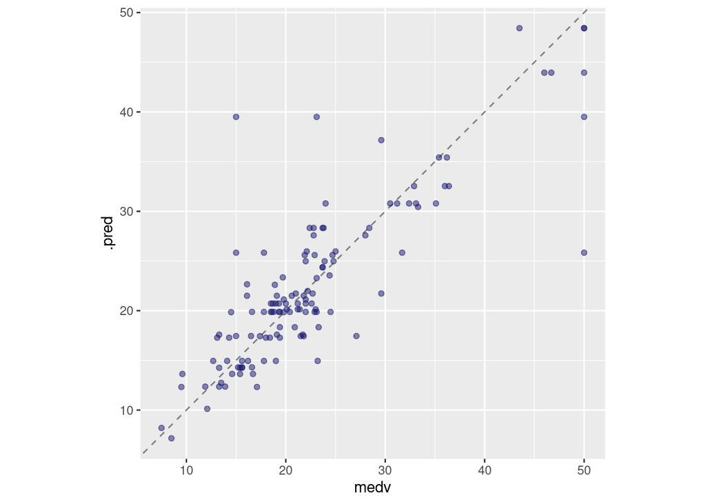

```r
collect_predictions(final_rs) %>%
  ggplot(aes(medv, .pred)) +
  geom_abline(lty = 2, color = "gray50") +
  geom_point(alpha = 0.5, color = "midnightblue") +
  coord_fixed()
```